# Sampling Distribution of the Sample Mean

ECON211 · Probability & Statistics

## Main question

Main question What can we learn about the population mean $\mu$ from a simple random sample?

Take a sample of $n=20$ student heights. We can compute the sample mean $\bar{x}$.

**How is $\bar{x}$ related to $\mu$?**

## Predict first

Write down your answers Population: heights of **373 students** from our class surveys. We draw random samples and compute the sample mean.

1. What is the **average height** $\mu$ of all 373 students?
2. For a sample of $n=20$, how far is $\bar{x}$ from $\mu$, typically: about **0.5, 2, 5 or 10 cm**?
3. With $n=5$ instead of $n=20$: is the histogram of $\bar{x}$ **wider or narrower**? By how much?
4. The heights of girls and boys form **two humps**. Will the histogram of $\bar{x}$ also have two humps?

## Try it: sample student heights

Population: **373 student heights** from our class surveys (cm). Draws are random, with replacement.

Reveal μ x̄ > 175

## $\bar{x}$ is not $\mu$

- They **don’t have to be equal**
- Every new sample gives a **different** $\bar{x}$
- Before we take the sample, the sample mean is a **random variable** $\bar{X}$; after, we observe a number $\bar{x}$
- **How close is it to the true mean?**

## Key observation

To answer, we need the **probability distribution** of $\bar{X}$.

It depends on two things:

**The population distribution**  
unknown!

**The sample size $n$**  
chosen by us

For now, assume we know the population distribution.

# Example: rolling a die

Population = a die. Sample = $n$ rolls.

## The population

$$P(X_i = x) = \tfrac{1}{6}, \qquad x \in \{1,2,3,4,5,6\}$$

The population is a **probability distribution** we draw from. The sample $X_1,\dots,X_n$ is independent draws from it. Hence, $X_1,\dots,X_n$ are **i.i.d.** r.v.’s with the same distribution as the population.

**Goal:** find the distribution of $\;\bar{X}=\frac{X_1+\dots+X_n}{n}$

## Histogram of the population

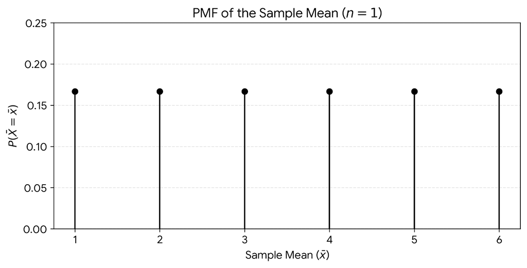

It looks exactly like the theoretical pmf

## Mean of one roll and of two rolls

n = 1 One observation has the population distribution: $X_1\sim DUnif$

n = 2 $\bar{X}=\frac{X_1+X_2}{2}$ takes the values $1,\ 1.5,\ 2,\ \dots,\ 5.5,\ 6$

## Deriving probabilities for $n=2$

$\bar{X}=1$ Sum must be 2: only $(1,1)$

$$P(\bar{X}=1)=\tfrac{1}{36}$$

$\bar{X}=3$ Sum must be 6: five outcomes, $(1,5),(2,4),(3,3),(4,2),(5,1)$

$$P(\bar{X}=3)=\tfrac{5}{36}$$

## pmf of $\bar{X}$ for $n=2$

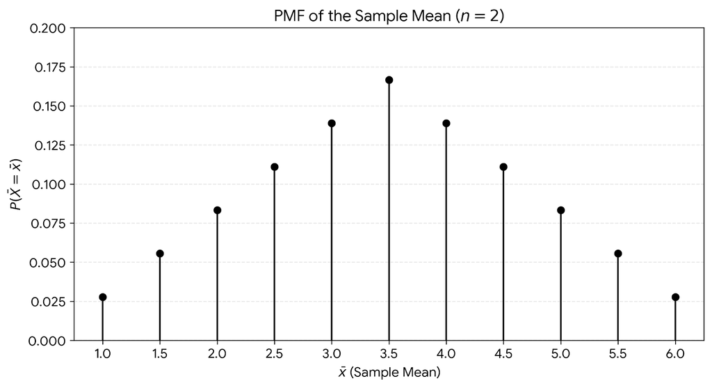

## pmf of $\bar{X}$ for $n=3$

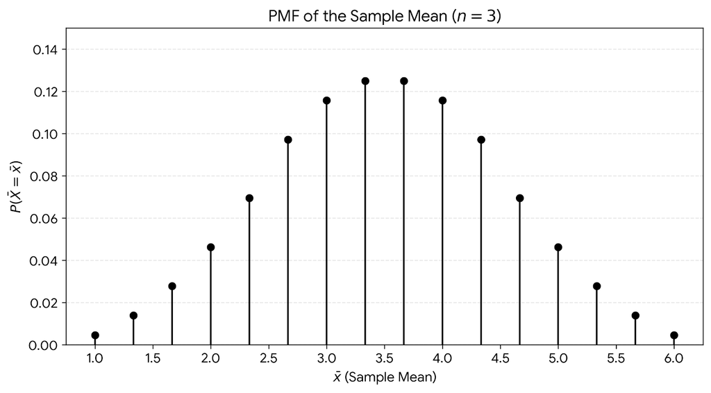

## pmf of $\bar{X}$ for any $n$

Move the slider and watch the shape.

Number of rolls **n = 4**

## What do we see?

Each $n$ gives a **different** distribution: supports and probabilities change.

But a **pattern** emerges: it concentrates around the mean and the tails die down.

The **shape stabilizes**.

## Too hard to derive? Simulate!

Draw 1000 samples of size $n$, compute $\bar{x}$ for each, and plot the histogram.

## Simulation: $n=20$

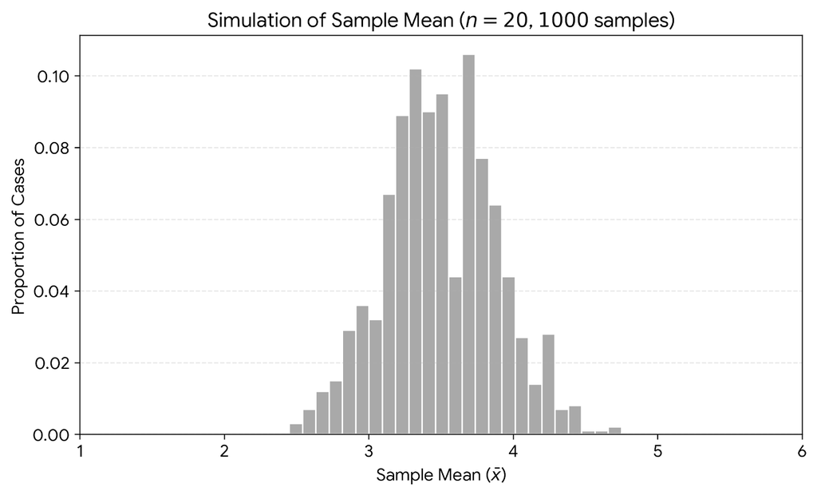

## Simulation: $n=200$

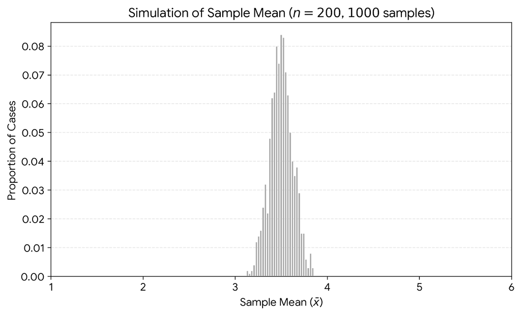

## Three main observations

1 · Center All distributions are **symmetric** and centered at $\mu=3.5$.

2 · Spread The **spread shrinks** as $n$ grows: $\bar{X}$ lands closer to $\mu$.

3 · Shape For large $n$ the shape becomes **bell-like**.

## Proof of (1): the center

$$E(\bar{X}) = E\!\left(\frac{\sum X_i}{n}\right)$$

$$= \frac{1}{n}\sum E(X_i)$$

$$= \frac{n\mu}{n} = \boxed{\mu}$$

On average, the sample mean equals the population mean.

## Predict: how much more data?

To cut the **standard deviation** of $\bar{X}$ in half, you need:

1. $2\times$ the data
2. $4\times$ the data
3. $\sqrt{2}\times$ the data
4. $10\times$ the data

$SD(\bar{X})=\sigma/\sqrt{n}$, and $\sqrt{4n}=2\sqrt{n}$. Doubling $n$ halves the **variance**, not the SD. Let’s prove it.

## Proof of (2): the spread

$$Var(\bar{X}) = Var\!\left(\frac{\sum X_i}{n}\right)$$

$$= \frac{1}{n^2}\sum Var(X_i)$$

$$= \frac{n\sigma^2}{n^2} = \boxed{\frac{\sigma^2}{n}}$$

The variance of one observation divided by $n$.

## Properties of the sample mean

Center
$$E(\bar{X})=\mu$$
The sample mean is **right on average**.

Spread
$$Var(\bar{X})=\frac{\sigma^2}{n}$$
More data means a **tighter** distribution: $SD(\bar{X})=\sigma/\sqrt{n}$, so $4\times$ the data halves the SD.

True for **any** population and **any** $n$: the derivation never used the shape.

## Quick check

A fair die has $\mu=3.5$ and $\sigma\approx1.71$. You roll it $n=25$ times. What is $SD(\bar{X})$?

1. $1.71$
2. $2.92$
3. $0.34$
4. $0.12$

$\sigma/\sqrt{n}=1.71/5\approx0.34$. $0.12=\sigma^2/n$ is the **variance**, and $1.71$ is the SD of a single roll.

Which of these changes when the sample size $n$ grows?

1. The population distribution
2. The population mean $\mu$
3. The distribution of $\bar{X}$
4. The population SD $\sigma$

The population is fixed. Only the distribution of $\bar{X}$ depends on $n$.

## Central Limit Theorem

In words Draw a **large random sample** from **any** population (finite mean and variance). Then the sample mean is **approximately Normal**: centered at $\mu$, with spread $\sigma/\sqrt{n}$.

In symbols If $X_1,\dots,X_n$ are i.i.d. with mean $\mu$ and variance $\sigma^2$, then
$$\bar{X}\ \approx\ N\!\left(\mu,\ \frac{\sigma^2}{n}\right)$$

The bigger the $n$ the better the Normal approximation

## The Normal pdf

Two parameters: mean and standard deviation.

Mean μ = **0.0** Std dev σ = **1.0**

## CLT in our dice example

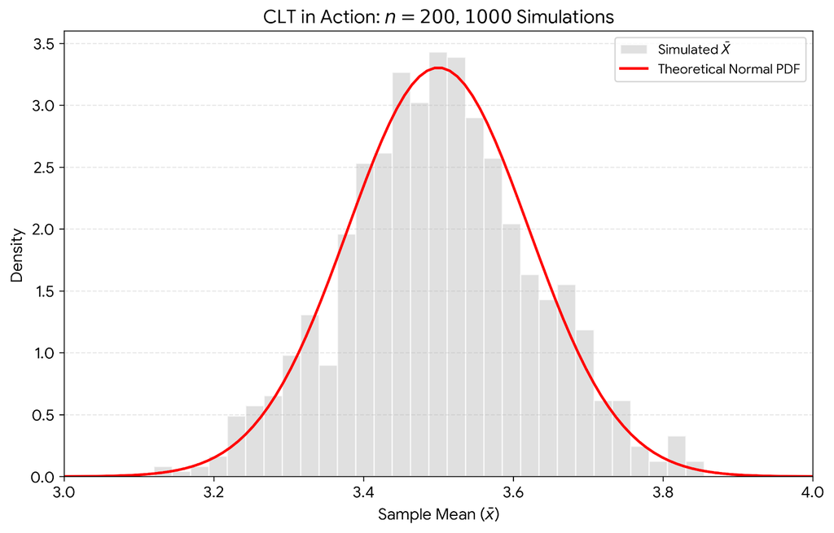

1000 simulated sample means with $n=200$ match the theoretical Normal curve

## The foundation of statistics

Takeaway No matter what the population looks like, for a large sample the sample mean follows a **Normal** distribution.

## Simulate the CLT

Population: Sample size n:

Show theoretical Normal

Blue line: average of all sample means so far. Try the bimodal population: $n=1$ is bimodal, $n=30$ is bell-shaped.

# The Normal distribution

## The standard Normal

Definition $Z\sim N(0,1)$: the Normal that is already **centered at 0** and **scaled to spread 1**.

pdf: the bell curve
$$\phi(z)=\frac{1}{\sqrt{2\pi}}e^{-z^2/2}$$

cdf: area to the left
$$\Phi(z)=P(Z\le z)$$

$\Phi$ has no closed form: use tables, Excel, or `scipy.stats.norm.cdf`.

## Core properties of $Z$

Center **Mean = 0**

the curve is centered at zero

Spread **Variance = SD = 1**

one unit = one standard deviation

Total area **Area = 1**

the constant $\tfrac{1}{\sqrt{2\pi}}$ makes it so

## Symmetry: left tail = right tail

z = **1.00**

$\Phi(0)=0.5$: half the area on each side

$\Phi(-z)=1-\Phi(z)$

## General Normal: $X\sim N(\mu,\sigma^2)$

Any Normal is a **shifted and stretched** standard Normal.

Location–scale
$$X=\mu+\sigma Z$$
$\mu$ shifts, $\sigma$ stretches

Standardization
$$Z=\frac{X-\mu}{\sigma}$$
the z-score: how many SDs from the mean

## See the transformation $X=\mu+\sigma Z$

μ = **2.0** σ = **1.5** z = **1.0**

## From $Z$ to the pdf of $X$: step 1

cdf of X
$$F_X(x)=P(X\le x)=P(\mu+\sigma Z\le x)$$

$$=P\!\left(Z\le\frac{x-\mu}{\sigma}\right)$$

$$F_X(x)=\Phi\!\left(\frac{x-\mu}{\sigma}\right)$$

## From $Z$ to the pdf of $X$: step 2

pdf = derivative of the cdf
$$f_X(x)=\frac{d}{dx}\,\Phi\!\left(\frac{x-\mu}{\sigma}\right)$$

chain rule, with $\Phi'=\phi$
$$=\phi\!\left(\frac{x-\mu}{\sigma}\right)\cdot\frac{1}{\sigma}$$

$$f_X(x)=\frac{1}{\sigma\sqrt{2\pi}}\,e^{-\frac{1}{2}\left(\frac{x-\mu}{\sigma}\right)^2}$$

## Why the factor $1/\sigma$?

Stretching by $\sigma$ spreads the **same total area** over a $\sigma$ times wider range.

So the curve gets $\sigma$ times **lower**: height $\propto 1/\sigma$. The area stays 1.

## Key properties of the Normal

Parameters $\mu=E[X]$

$\sigma^2=Var(X)$

Symmetry around $\mu$

mean = median = mode

Shape $\mu$ moves the curve,

$\sigma$ sets its width

## The 68–95–99.7 rule

Share of observations within $\pm1\sigma$, $\pm2\sigma$, $\pm3\sigma$ of the mean

## Probabilities for any Normal

**Recipe:** convert to a z-score, then look up $\Phi$.

$$P(X<x)=P\!\left(Z<\frac{x-\mu}{\sigma}\right)=\Phi\!\left(\frac{x-\mu}{\sigma}\right)$$

## Reading the standard Normal table

The table gives $\Phi(z)=P(Z\le z)$. **Row:** $z$ to one decimal. **Column:** the second decimal. (Excerpt for $z$ from $1.50$ to $2.29$.)

| z | .00 | .01 | .02 | .03 | .04 | .05 | .06 | .07 | .08 | .09 |
| --- | --- | --- | --- | --- | --- | --- | --- | --- | --- | --- |
| 1.5 | 0.9332 | 0.9345 | 0.9357 | 0.9370 | 0.9382 | 0.9394 | 0.9406 | 0.9418 | 0.9429 | 0.9441 |
| 1.6 | 0.9452 | 0.9463 | 0.9474 | 0.9484 | 0.9495 | 0.9505 | 0.9515 | 0.9525 | 0.9535 | 0.9545 |
| 1.7 | 0.9554 | 0.9564 | 0.9573 | 0.9582 | 0.9591 | 0.9599 | 0.9608 | 0.9616 | 0.9625 | 0.9633 |
| 1.8 | 0.9641 | 0.9649 | 0.9656 | 0.9664 | 0.9671 | 0.9678 | 0.9686 | 0.9693 | 0.9699 | 0.9706 |
| 1.9 | 0.9713 | 0.9719 | 0.9726 | 0.9732 | 0.9738 | 0.9744 | 0.9750 | 0.9756 | 0.9761 | 0.9767 |
| 2.0 | 0.9772 | 0.9778 | 0.9783 | 0.9788 | 0.9793 | 0.9798 | 0.9803 | 0.9808 | 0.9812 | 0.9817 |
| 2.1 | 0.9821 | 0.9826 | 0.9830 | 0.9834 | 0.9838 | 0.9842 | 0.9846 | 0.9850 | 0.9854 | 0.9857 |
| 2.2 | 0.9861 | 0.9864 | 0.9868 | 0.9871 | 0.9875 | 0.9878 | 0.9881 | 0.9884 | 0.9887 | 0.9890 |

Example: $\Phi(1.92)$ Row $1.9$ + column $.02$ $\Rightarrow$ $\Phi(1.92)=P(Z\le1.92)\approx\mathbf{0.9726}$

## Using the table: four cases

Below $P(Z\le1.92)=\Phi(1.92)$

$=0.9726$

Above $P(Z>1.92)=1-\Phi(1.92)$

$=0.0274$

Negative z (symmetry) $\Phi(-1.92)=1-\Phi(1.92)$

$=0.0274$

Between $P(-1.92\le Z\le1.92)$

$=\Phi(1.92)-\Phi(-1.92)=0.9452$

Tables list only $z\ge0$: for negative $z$ use $\Phi(-z)=1-\Phi(z)$. We will use $\Phi(1.92)$ on the next slide.

## Back to heights: $P(\bar{X}>175)$

Population: $\mu=171.24$ cm, $\sigma=8.76$ cm. Sample $n=20$ students. **How likely is a sample average above 175 cm?**

CLT $\bar{X}\approx N\!\left(\mu,\ \frac{\sigma^2}{n}\right)$

SD of $\bar{X}$ $\frac{8.76}{\sqrt{20}}\approx1.96$

z-score $\frac{175-171.24}{1.96}\approx1.92$

Probability
$$P(\bar{X}>175)\approx 1-\Phi(1.92)\approx 1-0.9726=0.027$$

## One student vs. an average of 20

One student $z=\frac{175-171.24}{8.76}\approx0.43$

$P(X>175)\approx0.33$

Average of 20 $z=\frac{175-171.24}{1.96}\approx1.92$

$P(\bar{X}>175)\approx0.027$

Check it yourself Go back to the heights widget: **All**, $n=20$, tick **$\bar{x}>175$**, press **+ 1000** a few times. The share should settle near $2.7\%$.

A tall student is common. A tall **average** of 20 students is rare: averaging cancels out the extremes.

## Practice: z-scores

Your answer:

Half the problems are about one observation, half about a **sample mean** (use $\sigma/\sqrt{n}$). Answers within $\pm0.005$ count as correct.

## Quick check

$X\sim N(170,\ 8^2)$. Approximately, $P(X>186)=$

1. $0.50$
2. $0.16$
3. $0.025$
4. $0.0015$

$186$ is $2\sigma$ above the mean. By the 68–95–99.7 rule, $5\%$ is outside $\pm2\sigma$, so $2.5\%$ is above.

Heights: $\sigma=8.76$. Compared with $n=20$, the SD of $\bar{X}$ for $n=80$ is:

1. $4\times$ smaller
2. $2\times$ smaller
3. the same
4. $2\times$ larger

$\sigma/\sqrt{80}=\sigma/(2\sqrt{20})$: four times the data halves the SD.

# Normal in real life

## Coin tosses

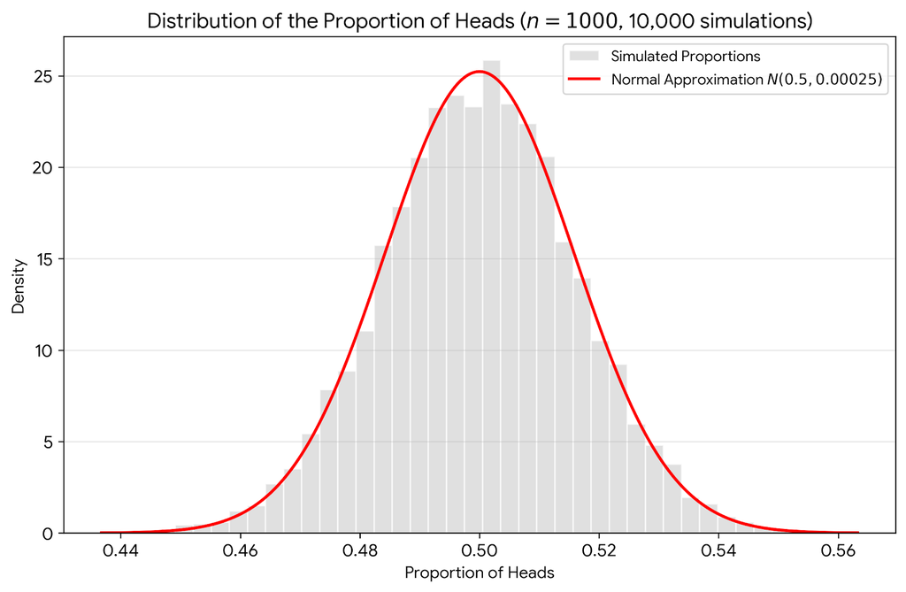

Proportion of heads in 1,000 tosses, repeated 10,000 times

## Human height

[figure not shown]

ECON211 female students, $n=226$, $\mu=166.0$ cm, $\sigma=5.6$ cm.  
Galton (1885): height is the sum of many small independent factors, so the **CLT** is at work.

## Weight

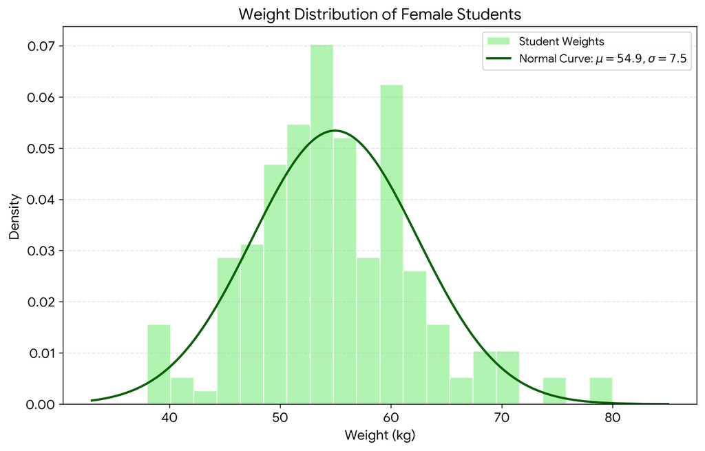

## SAT scores (2023)

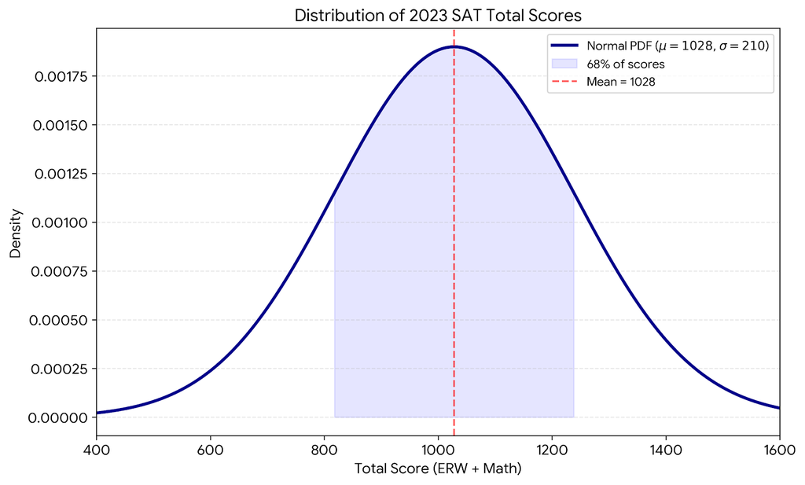

1.9 million test-takers. A score of 1550 is the **99.35th percentile**: about 6–7 in 1000 score higher.

## Our midterm scores

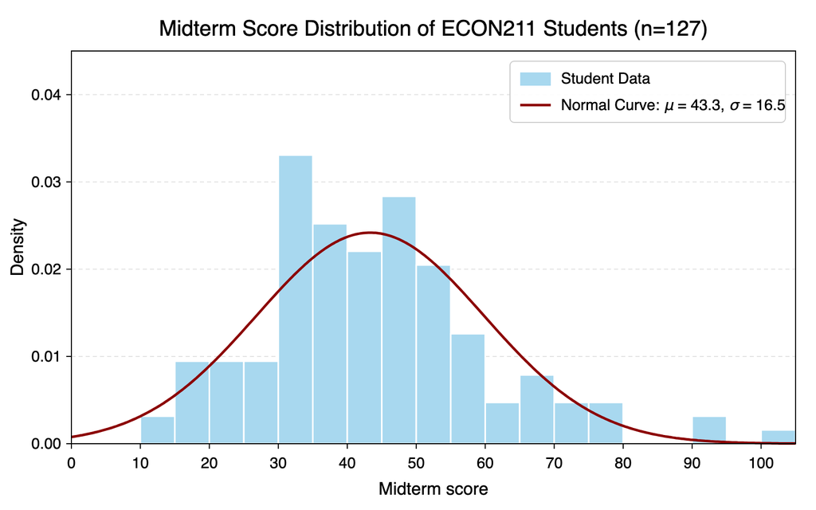

ECON211 midterm, $n=127$, mean $43.3$, SD $16.5$. Roughly bell-shaped; a few high scores stretch the right tail.

## Sleep (Garmin)

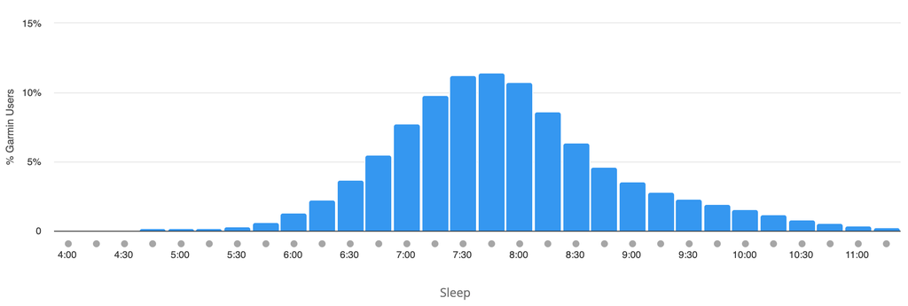

## Steps per day: not Normal

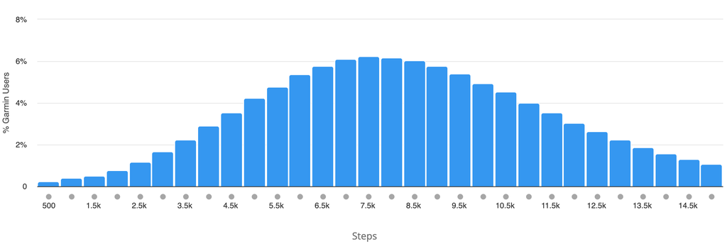

**Right skew**: the right tail is much heavier than the left.

## Something fishy: KROK 2015

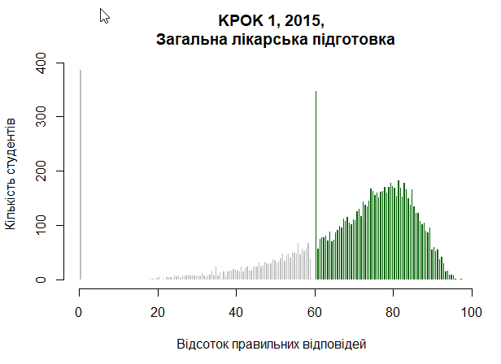

Ukrainian medical students’ exam results. Can you guess the issue?

## First-name lengths in this class

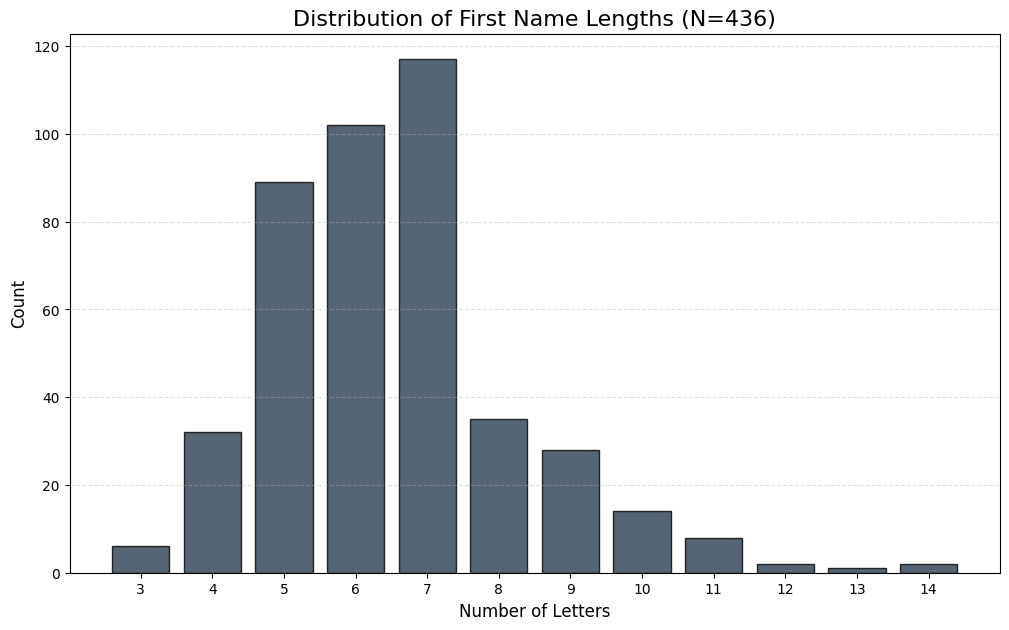

Again: notice the skew.

## Normal at the gym

[figure not shown]

# Using the Normal to approximate probabilities

## Example: coin toss proportions

Flip a fair coin $n=1000$ times. $X_i\sim \text{Bernoulli}(0.5)$ and $\hat{p}=\frac{1}{n}\sum X_i$.

Goal
$$P(\hat{p}<0.45)=\ ?$$

## Exact solution: Binomial

The number of heads $k\sim B(1000,0.5)$, and $\hat{p}<0.45 \iff k\le 449$.
$$P(K\le 449)=\sum_{k=0}^{449}\binom{1000}{k}(0.5)^{1000}$$

Exact
$$P\approx 0.000696$$

## Normal approximation: Step A

The CLT applies: $\hat{p}$ is an average of $n=1000$ iid Bernoulli variables.

Mean $\mu_{\hat p}=p=0.5$

Variance $\frac{p(1-p)}{n}=0.00025$

Standard error $\sqrt{0.00025}\approx0.0158$

## Normal approximation: Steps B and C

B · z-score
$$Z=\frac{0.45-0.5}{0.0158}\approx -3.16$$

C · probability
$$P(\hat{p}<0.45)\approx\Phi(-3.16)\approx 0.00079$$

## Exact vs. approximate

| Method | Probability | Comment |
| --- | --- | --- |
| **Binomial** (exact) | $0.000696$ | precise, heavy to compute |
| **Normal** (CLT) | $0.00079$ | right order of magnitude, about 13% too high |
| **Normal, continuity correction** | $0.00070$ | almost exact; see next slides |

A sum or average of many iid variables is approximately **Normal**, whatever the individual distribution.

## Continuity correction

Flip a fair coin $n=20$ times. $K$ = number of heads, so $K\sim B(20,\,0.5)$.

Goal
$$P(K=12)=\ ?$$

The Normal is continuous: $P(X=12)=0$. Fix: the integer $k$ occupies the interval $[k-0.5,\ k+0.5]$:
$$P(K=k)\approx P\big(k-0.5\le X\le k+0.5\big),\qquad X\sim N\big(np,\ np(1-p)\big)$$
Here $k$ is the specific number of heads we ask about ($k=12$).

In terms of $\hat p=K/n$: $\ P\!\left(\hat p=\tfrac{k}{n}\right)\approx P\!\left(\tfrac{k-0.5}{n}\le\hat p\le\tfrac{k+0.5}{n}\right)$ with $\hat p\sim N\!\left(p,\tfrac{p(1-p)}{n}\right)$.

## Continuity correction: the picture

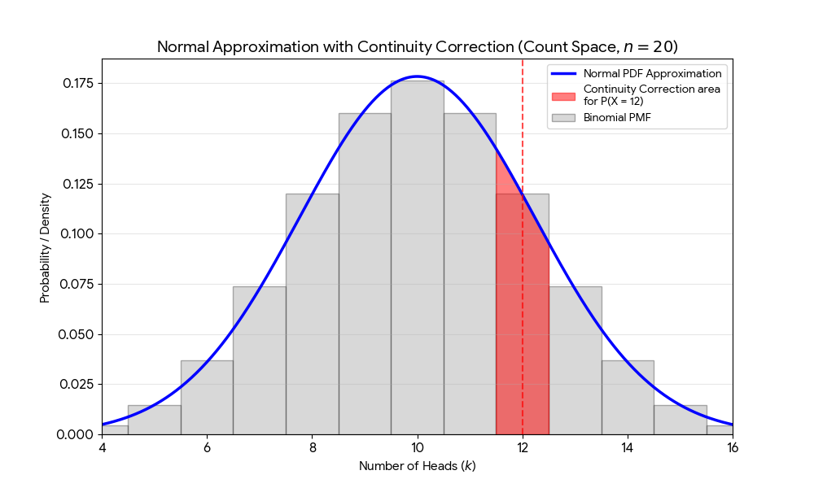

## Exact: $P(K=12)$

Exact (Binomial)
$$P(K=12)=\binom{20}{12}(0.5)^{20}=\frac{125970}{1048576}\approx 0.1201$$

## Normal approximation with correction

Mean $\mu=np=10$

Variance $np(1-p)=5$

Std. deviation $\sigma=\sqrt5\approx2.236$

z-scores
$$z_1=\frac{11.5-10}{2.236}\approx0.671,\qquad z_2=\frac{12.5-10}{2.236}\approx1.118$$

Probability
$$P(z_1\le Z\le z_2)\approx 0.8682-0.7488=0.1194$$

## Exact vs. Normal for $P(K=12)$

| Method | $P(K=12)$ |
| --- | --- |
| **Binomial** (exact) | $0.1201$ |
| **Normal, with correction** | $0.1194$ |
| **Normal, no correction** | $0$ |

With the correction the Normal is within $0.001$ of the exact answer, even for $n=20$.

## Exit ticket

Steps per day are **right-skewed**. You average steps over $n=100$ random days. The distribution of $\bar{X}$ is approximately:

1. right-skewed, like the population
2. Normal
3. uniform
4. impossible to say

CLT: for large $n$, $\bar{X}$ is approximately Normal whatever the population looks like.

$K\sim B(20,\,0.5)$. With the continuity correction, $P(K\le 8)\approx$

1. $P(X\le 8)$
2. $P(X\le 8.5)$
3. $P(X\le 7.5)$
4. $P(X\le 9.5)$

The value $8$ occupies $[7.5,\ 8.5]$, so “$\le 8$” ends at $8.5$.

## Exit ticket (continued)

“$E(\bar{X})=\mu$ holds only for large $n$.”

1. True: it comes from the CLT
2. False: it holds for any $n$

The proof only used linearity of expectation; the CLT is about the **shape**.

With $n=50$, $SD(\bar{X})=2$ cm. With $n=200$ from the same population it becomes:

1. $0.5$ cm
2. $1$ cm
3. $2$ cm
4. $4$ cm

$4\times$ the data: $SD(\bar{X})=\sigma/\sqrt{n}$ falls by $\sqrt4=2$.